# MA Survey Report: Paper 02 - Perceptual Distortion

Cheng Peng & Laura Pyatt

West Chester University

# 1 Introduction

Math anxiety (MA) is a pervasive phenomenon characterized by feelings of tension, apprehension, and fear when engaging with mathematical tasks (Ashcraft & Krause, 2007; Beilock & Willingham, 2014). Research consistently demonstrates a negative correlation between MA and math performance (Ramirez & Beilock, 2011), with anxious students underperforming their non-anxious peers across educational levels (Carey et al., 2017). The consequences extend beyond grades: MA is associated with reduced engagement in mathematics, avoidance of math-related courses and careers, and diminished self-efficacy (Bandura, 1997).

## 1.1 The Cognitive Mechanisms of Math Anxiety

Attentional Control Theory (ACT; Eysenck et al., 2007) provides a powerful framework for understanding MA’s cognitive effects. According to ACT, anxiety impairs the ability to maintain attentional focus on task-relevant information while inhibiting attention to distractors (Eysenck et al., 2007). Eye-tracking studies have demonstrated that math-anxious students exhibit deficits in attentional control during problem-solving, engaging attention to both task-relevant and task-irrelevant distractors (Beilock & Willingham, 2014; Mesghina et al., 2024). Critically, ACT suggests that anxious individuals preferentially attend to threat cues while neglecting neutral or supportive information (Eysenck et al., 2007; Zeidner, 1998). In the mathematics classroom, this “attentional bias” may manifest as a systematic distortion in how anxious students perceive teaching strategies. A teacher’s neutral question may be interpreted as a personal threat; a collaborative activity may be perceived as a public performance evaluation (Karabenick & Newman, 2006; Ryan & Pintrich, 1997).

## 1.2 The Learning Avoidance Model

The learning avoidance model proposes that math-anxious students engage in avoidance behaviors that perpetuate their difficulties (Ashcraft & Krause, 2007; Mesghina et al., 2024). Students with higher MA demonstrate less cognitive-behavioral and emotional engagement compared to their peers, and these engagement deficits partly account for achievement differences (Fredricks et al., 2004). Avoidance manifests in various contexts: negative homework behaviors, reduced participation in math-related extracurricular activities, and less effortful exam preparation (Wigfield & Meece, 1988).

This avoidance pattern may extend to how students process information about their learning environment. If anxious students are predisposed to avoid threatening stimuli, they may also avoid accurately processing pedagogical information that could challenge their negative beliefs about their mathematical abilities (Karabenick & Newman, 2006; Ryan & Pintrich, 1997).

## 1.3 Perceptual Distortion as a Missing Mechanism

Despite extensive research on MA’s cognitive and behavioral consequences, the role of perceptual distortion remains underexplored. The theoretical literature suggests that anxious individuals exhibit a “threat interpretation bias”—a tendency to interpret ambiguous stimuli as threatening (Eysenck et al., 2007; Zeidner, 1998). In educational contexts, this may manifest as systematic misperception of teaching strategies.

The survey instruments in this study are designed based on actual teaching strategies. Students report their perceptions on a Likert scale, where the scale endpoint (e.g., 5) represents accurate perception. Scores below this endpoint indicate perceptual distortion—students are not accurately perceiving the strategies as they are designed. This operationalization is novel and allows for a direct test of the distortion hypothesis.

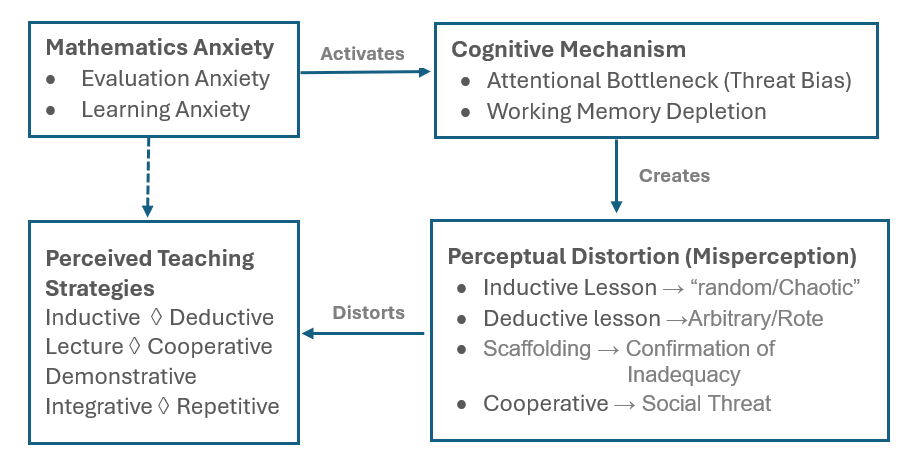

```r
include_graphics("Figure00.png")
```

Consider a student-centered activity designed to foster collaboration and conceptual understanding. A student who perceives this activity as highly teacher-centered (scoring low on student-centered items) is experiencing perceptual distortion. This filter may explain why pedagogical interventions often yield inconsistent effects: students do not “receive” the intended message (Birgin & Uzun Yazıcı, 2026; Tang, 2025).

## 1.4 Dimensions of Math

Math anxiety is not a unitary construct. Research consistently identifies distinct dimensions, particularly Evaluation Anxiety (EA)—fear of being judged or scrutinized during public mathematical performance—and Learning Anxiety (LA)—cognitive tension and fear experienced when grappling with unfamiliar mathematical concepts (Hopko, 2003; Wigfield & Meece, 1988). The Abbreviated Math Anxiety Scale (AMAS; Hopko et al., 2003) operationalizes these two dimensions, with demonstrated reliability across diverse populations (Caviola et al., 2017; Carey et al., 2017).

These dimensions may differentially relate to perceptual distortion. EA, being inherently social, may be particularly associated with distortion of student-centered activities that involve public participation. LA, being cognitive, may be associated with distortion of teacher-centered activities that are perceived as failing to provide conceptual clarity (Mesghina et al., 2024).

## 1.5 The Role of Self-Efficacy

Self-efficacy shapes how students interpret their learning environment (Bandura, 1997). Students with high self-efficacy may be less prone to perceptual distortion because they do not interpret ambiguous pedagogical cues as threatening. Conversely, students with low self-efficacy may be more prone to distortion because they are hypervigilant to potential failure cues (Bandura, 1997).

## 1.6 The Role of Engagement

Engagement is the behavioral manifestation of motivation and the most robust proximal predictor of academic achievement (Fredricks et al., 2004). In-class Social Engagement (ISE) involves participation, asking questions, and collaboration—activities that expose students to peer evaluation. After-class Behavioral Engagement (ABE) involves homework completion and practice—activities that build mastery (Wang et al., 2016). Perceptual distortion may mediate the relationship between math anxiety and engagement: anxious students distort their perceptions of teaching strategies, leading to disengagement.

# 2 Research Objectives and Hypotheses

**Objective 1**: To determine whether math anxiety predicts perceptual distortion of teaching strategies.

- **H1a**: High Evaluation Anxiety will be associated with greater perceptual distortion of student-centered teaching strategies (i.e., perceiving them as less student-centered than they are).
- **H1b**: High Learning Anxiety will be associated with greater perceptual distortion of teacher-centered teaching strategies (i.e., perceiving them as less supportive than they are).
- **H1c**: High math anxiety (both EA and LA) will be associated with greater overall perceptual distortion (deviation from scale midpoint across all items).

**Objective 2**: To determine whether perceptual distortion mediates the relationship between math anxiety and engagement.

- **H2a**: Perceptual distortion will mediate the EA → ISE pathway (anxious students distort perceptions, leading to reduced social engagement).
- **H2b**: Perceptual distortion will mediate the LA → ABE pathway (anxious students distort perceptions, leading to reduced behavioral engagement).

**Objective 3**: To test whether self-efficacy moderates the anxiety → distortion pathway.

- **H3**: Self-efficacy will moderate the relationship between math anxiety and perceptual distortion, such that the effect is weaker for high-efficacy students.

# 3 Method

## 3.2 Measures

- **Mathematics Anxiety**: Evaluated using the Abbreviated Math Anxiety Scale (AMAS), a 9-item instrument rated on a 5-point Likert scale ranging from 1 (not at all anxious) to 5 (very anxious). The scale yields two subscales: Math Evaluation Anxiety (MEA/EA; 4 items), measuring fear of public performance and scrutiny, and Math Learning Anxiety (MLA/LA; 5 items), measuring tension when grappling with mathematical concepts.
- **Perceived Teaching Strategies**: Assessed using a questionnaire based on actual instructional practices, comprising 8 items (4 teacher-centered, 4 student-centered) rated on a 5-point Likert scale. A score of 5 represents accurate perception, while lower scores reflect perceptual distortion.
- **Student Engagement**: Measured via the Math and Science Engagement Scale, evaluating two distinct dimensions on a 5-point Likert scale: In-class Social Engagement (ISE) (participation, asking questions, collaboration) and After-class Behavioral Engagement (ABE) (homework completion, practice, independent study).
- **Mathematics Self-Efficacy**: Measured using a 3-item standardized scale adapted from Rozgonjuk et al. (2020) assessing situation-specific beliefs about mathematical ability on a 5-point Likert scale (e.g., “I usually understand a mathematical idea quickly”), with one negatively worded item reverse-scored.
- **Auxiliary & Demographic Measures**: Learning preferences were assessed using the 24-item AVID Student Learning Modality Inventory. Single items captured participant gender, age, ethnicity, and course level

[output not shown]

## 3.3 Operationalization of Perceptual Distortion

Perceptual Distortion is operationalized as deviation from the scale midpoint (1 – 5, with 5 = accurate perception). Lower scores indicate greater distortion. This approach is based on the assumption that the survey instruments are designed to reflect actual teaching strategies, and a score of 5 represents accurate perception.

**Direction of Distortion**:

- Underestimation of Teacher-Centeredness: Perceived score < 5 on student-centered items (i.e., perceiving student-centered strategies as less student-centered).
- Underestimation of Supportiveness: Perceived score < 5 on teacher-centered items (i.e., perceiving teacher-centered strategies as less supportive).

## 3.4 Data Analysis Plan

**For Research Object 1**:

The diagram summarizes the linear regression models testing Objective 1, which examines whether math anxiety predicts perceptual distortion of teaching strategies. Three models are specified: H1a tests EA → student-centered distortion (β₁); H1b tests LA → teacher-centered distortion (β₂); and H1c uses multiple regression to test EA and LA → overall distortion (β₃, β₄). Two exploratory cross-paths (β₅, β₆) are also estimated. The multiple regression for H1c partitions the unique variance explained by each anxiety dimension while controlling for the other, yielding an overall R².

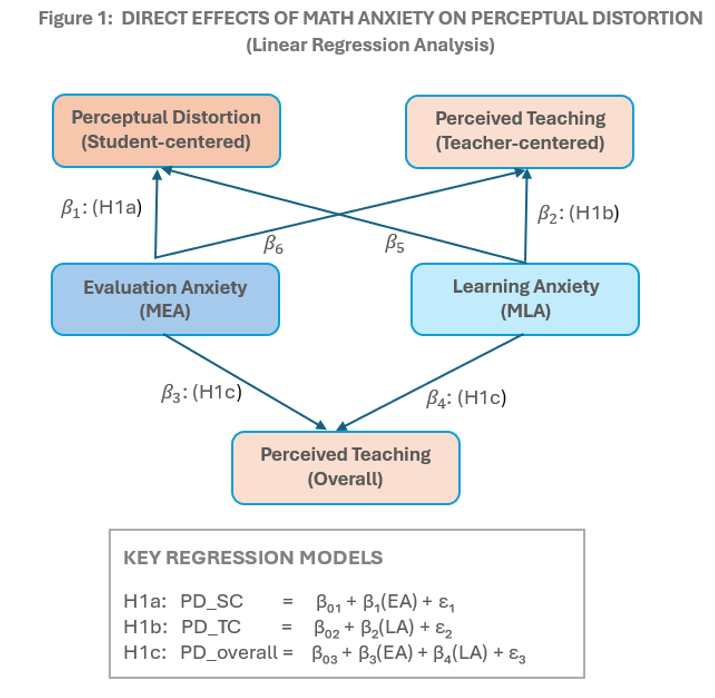

```r
include_graphics("Figure02.png")
```

**For Research Objectives 2 and 3**

Figure 2 presents a moderated mediation model tested via structural equation modeling. Math anxiety dimensions, Evaluation Anxiety (EA) and Learning Anxiety (LA), serve as predictors, while Perceptual Distortion is modeled as two parallel mediators: student-centered distortion (PD_SC) and teacher-centered distortion (PD_TC). In-class social engagement (ISE) and after-class behavioral engagement (ABE) serve as outcomes. Self-efficacy (SE) functions as the moderator, acting on all four a-paths linking predictors to mediators (SE × EA → PD_SC, SE × EA → PD_TC, SE × LA → PD_SC, SE × LA → PD_TC), as specified in H3.

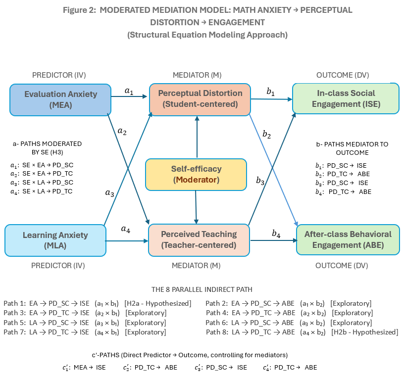

```r
include_graphics("Figure01.png")
```

The model estimates eight parallel indirect effects formed by the products of a-paths and b-paths, of which two are hypothesized: H2a (EA → PD_SC → ISE; a₁ × b₁) and H2b (LA → PD_TC → ABE; a₄ × b₄). The remaining six are exploratory cross-paths linking each predictor to the non-hypothesized mediator and outcome combinations. Four direct c′-paths (predictor → outcome, controlling for mediators) are also estimated to test partial versus full mediation. All a-paths are conditional on self-efficacy, allowing the indirect effects to vary across levels of the moderator.

# 4 Results

```r
sapply(dat, function(x) c(M = mean(x, na.rm = TRUE),
                          SD = sd(x,   na.rm = TRUE)))
```

```
              EA           LA          SE       PD_SC       PD_TC         ISE
M  -0.0001404311 -0.001712311 0.004548909 0.001769031 0.001230181 0.004574985
SD  0.9837992207  0.433278312 1.708739716 0.588425094 0.645284496 0.624775356
           ABE  PD_overall
M  0.002291349 0.001499606
SD 0.443904373 0.607784457
```

The correlation coefficient matrix is given by

```r
cor(dat)
```

```
                    EA          LA          SE       PD_SC      PD_TC
EA          1.00000000  0.58555380 -0.43162862  0.23767348  0.2878328
LA          0.58555380  1.00000000 -0.44153035  0.29837513  0.3531322
SE         -0.43162862 -0.44153035  1.00000000 -0.22829112 -0.2713692
PD_SC       0.23767348  0.29837513 -0.22829112  1.00000000  0.9414915
PD_TC       0.28783281  0.35313216 -0.27136919  0.94149147  1.0000000
ISE        -0.12730844 -0.13785271  0.17232647 -0.22128240 -0.2286030
ABE         0.08450291 -0.08225813  0.07705966 -0.09860477 -0.0961244
PD_overall  0.26784749  0.33189572 -0.25456604  0.98386437  0.9866012
                  ISE         ABE PD_overall
EA         -0.1273084  0.08450291  0.2678475
LA         -0.1378527 -0.08225813  0.3318957
SE          0.1723265  0.07705966 -0.2545660
PD_SC      -0.2212824 -0.09860477  0.9838644
PD_TC      -0.2286030 -0.09612440  0.9866012
ISE         1.0000000  0.25602212 -0.2284709
ABE         0.2560221  1.00000000 -0.0987596
PD_overall -0.2284709 -0.09875960  1.0000000
```

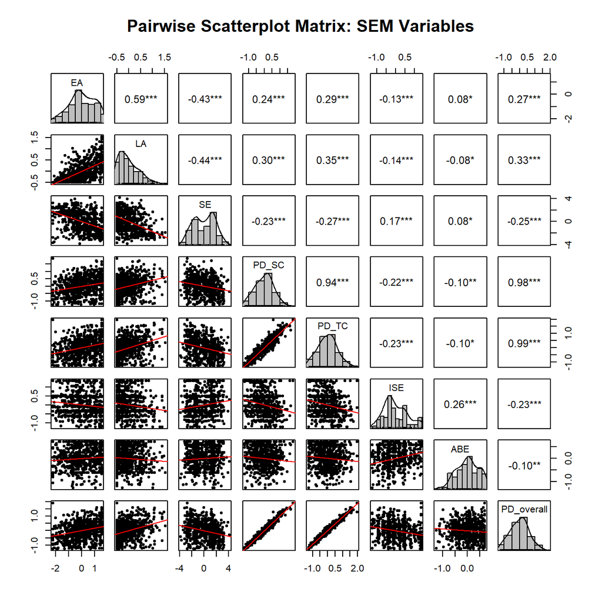

```r
psych::pairs.panels(
  dat,
  method      = "pearson",   # or "spearman"
  hist.col    = "gray",
  density     = TRUE,
  ellipses    = FALSE,
  stars       = TRUE,        # stars instead of raw p
  lm          = TRUE,        # fit regression line
  smooth      = FALSE,
  #scale       = TRUE,
  cex         = 0.8,
  cex.labels  = 1,
  main        = "Pairwise Scatterplot Matrix: SEM Variables"
)
```

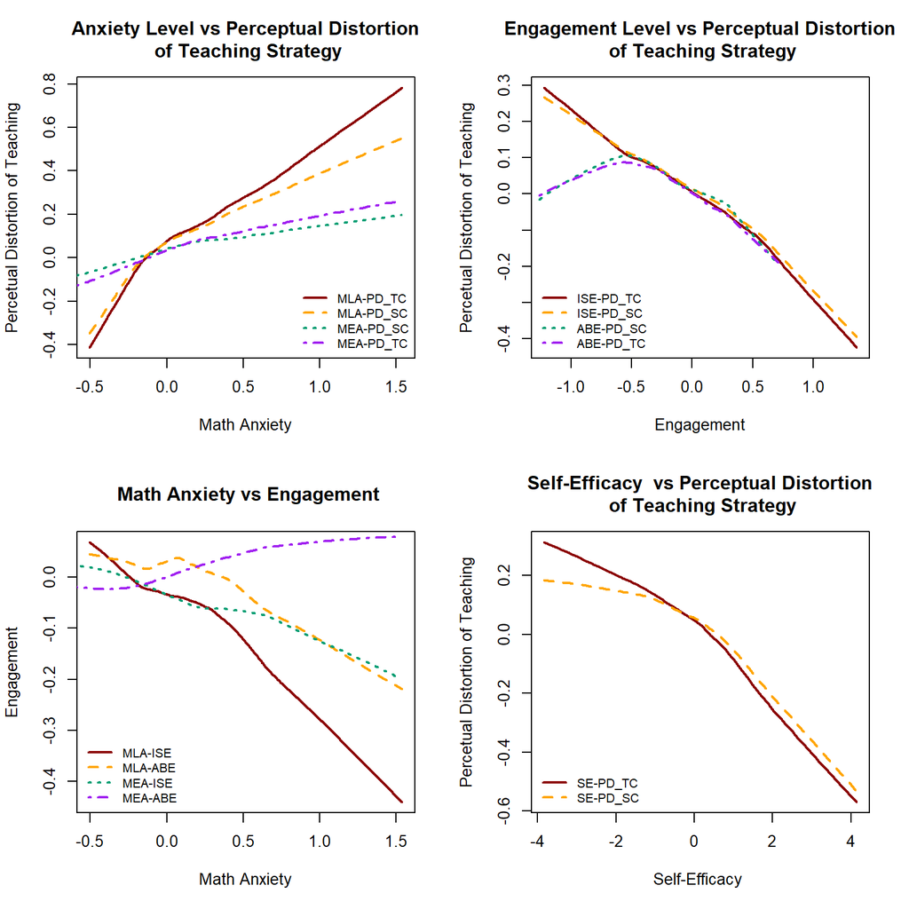

```r
par(mfrow=c(2,2))
mycol <- c("darkred", "orange", "#009E73", "purple")
#
plot(lowess(dat$LA, dat$PD_TC), type = "l", col = mycol[1], lwd = 2, lty = 1,
     main = " Anxiety Level vs Perceptual Distortion \n of Teaching Strategy",
     xlab = "Math Anxiety", ylab = "Percetual Distortion of Teaching")
lines(lowess(dat$LA, dat$PD_SC), col = mycol[2], lwd = 2, lty = 2)
lines(lowess(dat$EA, dat$PD_SC), col = mycol[3], lwd = 2, lty = 3)
lines(lowess(dat$EA, dat$PD_TC), col = mycol[4], lwd = 2, lty = 4)
legend("bottomright", c("MLA-PD_TC", "MLA-PD_SC", "MEA-PD_SC", "MEA-PD_TC"),
       col = mycol, lwd = rep(2,4), lty = 1:4, cex = 0.8, bty = "n")
##
plot(lowess(dat$ISE, dat$PD_TC), type = "l", col = mycol[1], lwd = 2, lty = 1,
     main = " Engagement Level vs Perceptual Distortion \n of Teaching Strategy",
     xlab = "Engagement", ylab = "Percetual Distortion of Teaching")
lines(lowess(dat$ISE, dat$PD_SC), col = mycol[2], lwd = 2, lty = 2)
lines(lowess(dat$ABE, dat$PD_SC), col = mycol[3], lwd = 2, lty = 3)
lines(lowess(dat$ABE, dat$PD_TC), col = mycol[4], lwd = 2, lty = 4)
legend("bottomleft", c("ISE-PD_TC", "ISE-PD_SC", "ABE-PD_SC", "ABE-PD_TC"),
       col = mycol, lwd = rep(2,4), lty = 1:4, cex = 0.8, bty = "n")
##
plot(lowess(dat$LA, dat$ISE), type = "l", col = mycol[1], lwd = 2, lty = 1,
     main = " Math Anxiety vs Engagement",
     xlab = "Math Anxiety", ylab = "Engagement")
lines(lowess(dat$LA, dat$ABE), col = mycol[2], lwd = 2, lty = 2)
lines(lowess(dat$EA, dat$ISE), col = mycol[3], lwd = 2, lty = 3)
lines(lowess(dat$EA, dat$ABE), col = mycol[4], lwd = 2, lty = 4)
legend("bottomleft", c("MLA-ISE", "MLA-ABE", "MEA-ISE", "MEA-ABE"),
       col = mycol, lwd = rep(2,4), lty = 1:4, cex = 0.8, bty = "n")
##
plot(lowess(dat$SE, dat$PD_TC), type = "l", col = mycol[1], lwd = 2, lty = 1,
     main = " Self-Efficacy  vs Perceptual Distortion \n of Teaching Strategy",
     xlab = "Self-Efficacy ", ylab = "Percetual Distortion of Teaching")
lines(lowess(dat$SE, dat$PD_SC), col = mycol[2], lwd = 2, lty = 2)
legend("bottomleft", c("SE-PD_TC", "SE-PD_SC" ),
       col = mycol[c(1,2)], lwd = rep(2,2), lty = 1:2, cex = 0.8, bty = "n")
```

```r
###############################################################################
# FIGURE 1:
#   H1a: PD_SC ~ EA          (beta_1)
#   H1b: PD_TC ~ LA          (beta_2)
#   H1c: PD_overall ~ EA + LA (beta_3, beta_4)
#   Exploratory cross-paths  (beta_5, beta_6) are also estimated.
###############################################################################

# FIGURE 1 -- Linear regression models (Objective 1)
###############################################################################
cat("\n========== FIGURE 1: Linear Regressions ==========\n")
```

```
========== FIGURE 1: Linear Regressions ==========
```

```r
fit_h1a <- lm(PD_SC ~ EA_c, data = datSEM)                 # H1a
fit_h1b <- lm(PD_TC ~ LA_c, data = datSEM)                 # H1b
fit_h1c <- lm(PD_overall ~ EA_c + LA_c, data = datSEM)     # H1c
fit_cross_sc <- lm(PD_SC ~ EA_c + LA_c, data = datSEM)     # exploratory beta5
fit_cross_tc <- lm(PD_TC ~ EA_c + LA_c, data = datSEM)     # exploratory beta6

cat("\n--- H1a: PD_SC ~ EA ---\n");            print(summary(fit_h1a))
```

```
--- H1a: PD_SC ~ EA ---
```

```
Call:
lm(formula = PD_SC ~ EA_c, data = datSEM)

Residuals:
     Min       1Q   Median       3Q      Max
-1.41636 -0.39921  0.03411  0.39056  2.17016

Coefficients:
            Estimate Std. Error t value Pr(>|t|)
(Intercept) 0.001769   0.021728   0.081    0.935
EA_c        0.142156   0.022101   6.432 2.35e-10 ***
---
Signif. codes:  0 '***' 0.001 '**' 0.01 '*' 0.05 '.' 0.1 ' ' 1

Residual standard error: 0.572 on 691 degrees of freedom
Multiple R-squared:  0.05649,   Adjusted R-squared:  0.05512
F-statistic: 41.37 on 1 and 691 DF,  p-value: 2.351e-10
```

```r
cat("\n--- H1b: PD_TC ~ LA ---\n");            print(summary(fit_h1b))
```

```
--- H1b: PD_TC ~ LA ---
```

```
Call:
lm(formula = PD_TC ~ LA_c, data = datSEM)

Residuals:
     Min       1Q   Median       3Q      Max
-1.80745 -0.38082  0.00854  0.39490  2.23183

Coefficients:
            Estimate Std. Error t value Pr(>|t|)
(Intercept)  0.00123    0.02295   0.054    0.957
LA_c         0.52592    0.05301   9.922   <2e-16 ***
---
Signif. codes:  0 '***' 0.001 '**' 0.01 '*' 0.05 '.' 0.1 ' ' 1

Residual standard error: 0.6041 on 691 degrees of freedom
Multiple R-squared:  0.1247,    Adjusted R-squared:  0.1234
F-statistic: 98.45 on 1 and 691 DF,  p-value: < 2.2e-16
```

```r
cat("\n--- H1c: PD_overall ~ EA + LA ---\n");  print(summary(fit_h1c))
```

```
--- H1c: PD_overall ~ EA + LA ---
```

```
Call:
lm(formula = PD_overall ~ EA_c + LA_c, data = datSEM)

Residuals:
     Min       1Q   Median       3Q      Max
-1.68778 -0.36129  0.01152  0.38336  2.25229

Coefficients:
            Estimate Std. Error t value Pr(>|t|)
(Intercept)  0.00150    0.02171   0.069   0.9449
EA_c         0.06910    0.02724   2.537   0.0114 *
LA_c         0.37369    0.06186   6.041  2.5e-09 ***
---
Signif. codes:  0 '***' 0.001 '**' 0.01 '*' 0.05 '.' 0.1 ' ' 1

Residual standard error: 0.5715 on 690 degrees of freedom
Multiple R-squared:  0.1184,    Adjusted R-squared:  0.1158
F-statistic: 46.32 on 2 and 690 DF,  p-value: < 2.2e-16
```

```r
cat("\n--- Cross: PD_SC ~ EA + LA ---\n");     print(summary(fit_cross_sc))
```

```
--- Cross: PD_SC ~ EA + LA ---
```

```
Call:
lm(formula = PD_SC ~ EA_c + LA_c, data = datSEM)

Residuals:
     Min       1Q   Median       3Q      Max
-1.59003 -0.37029  0.01261  0.36685  2.14670

Coefficients:
            Estimate Std. Error t value Pr(>|t|)
(Intercept) 0.001769   0.021294   0.083   0.9338
EA_c        0.057305   0.026721   2.145   0.0323 *
LA_c        0.329026   0.060672   5.423 8.11e-08 ***
---
Signif. codes:  0 '***' 0.001 '**' 0.01 '*' 0.05 '.' 0.1 ' ' 1

Residual standard error: 0.5606 on 690 degrees of freedom
Multiple R-squared:  0.09506,   Adjusted R-squared:  0.09244
F-statistic: 36.24 on 2 and 690 DF,  p-value: 1.081e-15
```

```r
cat("\n--- Cross: PD_TC ~ EA + LA ---\n");     print(summary(fit_cross_tc))
```

```
--- Cross: PD_TC ~ EA + LA ---
```

```
Call:
lm(formula = PD_TC ~ EA_c + LA_c, data = datSEM)

Residuals:
     Min       1Q   Median       3Q      Max
-1.78553 -0.39834 -0.00433  0.38821  2.35788

Coefficients:
            Estimate Std. Error t value Pr(>|t|)
(Intercept)  0.00123    0.02284   0.054  0.95705
EA_c         0.08091    0.02865   2.824  0.00489 **
LA_c         0.41835    0.06506   6.430 2.38e-10 ***
---
Signif. codes:  0 '***' 0.001 '**' 0.01 '*' 0.05 '.' 0.1 ' ' 1

Residual standard error: 0.6011 on 690 degrees of freedom
Multiple R-squared:  0.1347,    Adjusted R-squared:  0.1322
F-statistic: 53.71 on 2 and 690 DF,  p-value: < 2.2e-16
```

```r
cat("\n--- Robust HC3 SEs (H1a, H1b, H1c) ---\n")
```

```
--- Robust HC3 SEs (H1a, H1b, H1c) ---
```

```r
print(coeftest(fit_h1a, vcov. = vcovHC(fit_h1a, type = "HC3")))
```

```
t test of coefficients:

            Estimate Std. Error t value  Pr(>|t|)
(Intercept) 0.001769   0.021762  0.0813    0.9352
EA_c        0.142156   0.023153  6.1400 1.392e-09 ***
---
Signif. codes:  0 '***' 0.001 '**' 0.01 '*' 0.05 '.' 0.1 ' ' 1
```

```r
print(coeftest(fit_h1b, vcov. = vcovHC(fit_h1b, type = "HC3")))
```

```
t test of coefficients:

             Estimate Std. Error t value Pr(>|t|)
(Intercept) 0.0012302  0.0229934  0.0535   0.9573
LA_c        0.5259223  0.0610098  8.6203   <2e-16 ***
---
Signif. codes:  0 '***' 0.001 '**' 0.01 '*' 0.05 '.' 0.1 ' ' 1
```

```r
print(coeftest(fit_h1c, vcov. = vcovHC(fit_h1c, type = "HC3")))
```

```
t test of coefficients:

             Estimate Std. Error t value  Pr(>|t|)
(Intercept) 0.0014996  0.0217648  0.0689    0.9451
EA_c        0.0691049  0.0275629  2.5072    0.0124 *
LA_c        0.3736904  0.0664276  5.6255 2.689e-08 ***
---
Signif. codes:  0 '***' 0.001 '**' 0.01 '*' 0.05 '.' 0.1 ' ' 1
```

```r
cat("\n--- VIF for H1c ---\n"); print(vif(fit_h1c))
```

```
--- VIF for H1c ---
```

```
    EA_c     LA_c
1.521776 1.521776
```

```r
###############################################################################
# FIGURE 2: MODERATED MEDIATION MODEL (Structural Equation Modeling Approach)
#
#   Predictors : EA, LA
#   Mediators  : PD_SC, PD_TC
#   Outcomes   : ISE, ABE
#   Moderator  : SE (acts on all four a-paths: EA->PD_SC, EA->PD_TC,
#                   LA->PD_SC, LA->PD_TC)
#
#   Hypothesized indirect paths:
#     H2a: EA -> PD_SC -> ISE   (a1 * b1)
#     H2b: LA -> PD_TC -> ABE   (a4 * b4)
#
#   Exploratory cross-paths (the other 6 of the 8 parallel indirect paths):
#     EA -> PD_SC -> ABE ; EA -> PD_TC -> ISE ; EA -> PD_TC -> ABE
#     LA -> PD_SC -> ISE ; LA -> PD_SC -> ABE ; LA -> PD_TC -> ISE
#
#   c'-paths (direct effects) are also estimated.
###############################################################################

cat("\n=============================================================\n")
cat("FIGURE 2: Moderated Mediation SEM (Objective 2)\n")
```

```
FIGURE 2: Moderated Mediation SEM (Objective 2)
```

```r
cat("=============================================================\n")
```

```r
# --- Specify the lavaan model ----------------------------------------------
# Notes:
#   * We use observed composites (single-indicator) here because the
#     manuscript reports subscale scores rather than latent factors.
#     If item-level data are available, replace each composite with a
#     measurement model (e.g., EA =~ ea1 + ea2 + ea3 + ea4).
#   * Product terms (EA_c:SE_c, etc.) implement the moderation of a-paths.
#   * `a1`..`a4` are the conditional a-paths at SE = 0 (mean SE).
#   * `b1`..`b4` are the b-paths.
#   * `ind_*` are the 8 parallel indirect effects.
#   * `cp_*`  are the 4 direct (c') paths.
  # PD_SC ~ a1*EA_c + a2*LA_c + a3*EA_c:SE_c + a4*LA_c:SE_c
  # PD_TC ~ a5*EA_c + a6*LA_c + a7*EA_c:SE_c + a8*LA_c:SE_c
# ---------------------------------------------------------------------------
cat("\n========== FIGURE 2: Moderated Mediation SEM ==========\n")
```

```
========== FIGURE 2: Moderated Mediation SEM ==========
```

```r
## ---- Model syntax ---------------------------------------------------------
## Product terms EAxSE and LAxSE are already columns in `dat`.
model_fig2 <- '
  # ---- a-paths (mediator equations) ----
  PD_SC ~ a1*EA_c + a2*LA_c + a3*EAxSE + a4*LAxSE
  PD_TC ~ a5*EA_c + a6*LA_c + a7*EAxSE + a8*LAxSE

  # ---- b-paths and c\'-paths (outcome equations) ----
  ISE ~ b1*PD_SC + b2*PD_TC + cp1*EA_c + cp2*LA_c
  ABE ~ b3*PD_SC + b4*PD_TC + cp3*EA_c + cp4*LA_c

  # ---- Covariances ----
  EA_c ~~ LA_c
  PD_SC ~~ PD_TC

  # ---- 8 parallel indirect effects (a * b) ----
  ind_EA_SC_ISE := a1*b1     # H2a
  ind_EA_SC_ABE := a1*b3
  ind_EA_TC_ISE := a5*b2
  ind_EA_TC_ABE := a5*b4
  ind_LA_SC_ISE := a2*b1
  ind_LA_SC_ABE := a2*b3
  ind_LA_TC_ISE := a6*b2
  ind_LA_TC_ABE := a6*b4     # H2b

  # ------------------- Conditional indirect effects -----------------
  # (computed at low/mean/high SE via lavaan\'s := with moderator values)
  # We define them as functions of SE below using `lavaan`\'s
  # `defined` parameter (see section "Conditional indirect effects").
'
## ---- (A) Fit with MLR for fit indices and robust SEs ---------------------
fit_mlr <- sem(model_fig2, data = datSEM, estimator = "MLR",
               missing = "fiml", se = "robust")

cat("\n--- MLR fit measures ---\n")
```

```
--- MLR fit measures ---
```

```r
print(fitMeasures(fit_mlr,
      fit.measures = c("chisq.scaled","df.scaled","pvalue.scaled",
                       "cfi.robust","tli.robust",
                       "rmsea.robust","rmsea.ci.lower.robust",
                       "rmsea.ci.upper.robust",
                       "srmr","aic","bic")))
```

```
         chisq.scaled             df.scaled         pvalue.scaled
               74.666                 8.000                 0.000
           cfi.robust            tli.robust          rmsea.robust
                0.956                 0.850                 0.130
rmsea.ci.lower.robust rmsea.ci.upper.robust                  srmr
                0.104                 0.158                 0.059
                  aic                   bic
             5521.950              5662.722
```

```r
cat("\n--- Standardized parameter estimates ---\n")
```

```
--- Standardized parameter estimates ---
```

```r
print(parameterEstimates(fit_mlr, standardized = TRUE, ci = TRUE))
```

```
             lhs op   rhs         label    est    se      z pvalue ci.lower
1          PD_SC  ~  EA_c            a1  0.058 0.027  2.137  0.033    0.005
2          PD_SC  ~  LA_c            a2  0.316 0.070  4.520  0.000    0.179
3          PD_SC  ~ EAxSE            a3  0.024 0.017  1.418  0.156   -0.009
4          PD_SC  ~ LAxSE            a4 -0.037 0.042 -0.869  0.385   -0.119
5          PD_TC  ~  EA_c            a5  0.085 0.029  2.919  0.004    0.028
6          PD_TC  ~  LA_c            a6  0.386 0.074  5.215  0.000    0.241
7          PD_TC  ~ EAxSE            a7  0.025 0.018  1.391  0.164   -0.010
8          PD_TC  ~ LAxSE            a8 -0.064 0.045 -1.416  0.157   -0.154
9            ISE  ~ PD_SC            b1 -0.085 0.112 -0.759  0.448   -0.304
10           ISE  ~ PD_TC            b2 -0.121 0.104 -1.156  0.247   -0.326
11           ISE  ~  EA_c           cp1 -0.030 0.030 -1.000  0.317   -0.090
12           ISE  ~  LA_c           cp2 -0.060 0.066 -0.911  0.362   -0.190
13           ABE  ~ PD_SC            b3 -0.046 0.084 -0.553  0.580   -0.211
14           ABE  ~ PD_TC            b4 -0.026 0.078 -0.332  0.740   -0.178
```

[output cut: 75 more lines]

```r
## ---- (B) Refit with ML + bootstrap for indirect-effect CIs ----------------
fit_boot <- sem(model_fig2, data = datSEM, estimator = "ML",
                se = "bootstrap", bootstrap = 5000)

cat("\n--- Bootstrapped 95% CIs for indirect effects ---\n")
```

```
--- Bootstrapped 95% CIs for indirect effects ---
```

```r
print(parameterEstimates(fit_boot, boot.ci.type = "bca.simple",
                         ci = TRUE, level = 0.95))
```

```
             lhs op   rhs         label    est    se      z pvalue ci.lower
1          PD_SC  ~  EA_c            a1  0.058 0.027  2.154  0.031    0.004
2          PD_SC  ~  LA_c            a2  0.316 0.070  4.518  0.000    0.176
3          PD_SC  ~ EAxSE            a3  0.024 0.017  1.404  0.160   -0.009
4          PD_SC  ~ LAxSE            a4 -0.037 0.042 -0.871  0.384   -0.122
5          PD_TC  ~  EA_c            a5  0.085 0.029  2.925  0.003    0.026
6          PD_TC  ~  LA_c            a6  0.386 0.074  5.211  0.000    0.235
7          PD_TC  ~ EAxSE            a7  0.025 0.018  1.391  0.164   -0.010
8          PD_TC  ~ LAxSE            a8 -0.064 0.045 -1.425  0.154   -0.155
9            ISE  ~ PD_SC            b1 -0.085 0.112 -0.756  0.450   -0.317
10           ISE  ~ PD_TC            b2 -0.121 0.105 -1.151  0.250   -0.331
11           ISE  ~  EA_c           cp1 -0.030 0.030 -0.996  0.319   -0.089
12           ISE  ~  LA_c           cp2 -0.060 0.067 -0.904  0.366   -0.191
13           ABE  ~ PD_SC            b3 -0.046 0.085 -0.549  0.583   -0.216
14           ABE  ~ PD_TC            b4 -0.026 0.078 -0.328  0.743   -0.180
```

[output cut: 59 more lines]

```r
###############################################################################
# Conditional indirect effects at low / mean / high self-efficacy (Table 4)
# Implemented in lavaan with the `defined` parameter.
###############################################################################
cat("\n========== Conditional Indirect Effects by Self-Efficacy ==========\n")
```

```
========== Conditional Indirect Effects by Self-Efficacy ==========
```

```r
sdSE <- sd(datSEM$SE_c, na.rm = TRUE)

model_cond_str <- sprintf('
  PD_SC ~ a1*EA_c + a2*LA_c + a3*EAxSE + a4*LAxSE
  PD_TC ~ a5*EA_c + a6*LA_c + a7*EAxSE + a8*LAxSE
  ISE   ~ b1*PD_SC + b2*PD_TC
  ABE   ~ b3*PD_SC + b4*PD_TC
  EA_c  ~~ LA_c
  PD_SC ~~ PD_TC

  a1_low  := a1 + a3*(%1$f)
  a1_mean := a1
  a1_high := a1 + a3*(%2$f)
  a6_low  := a6 + a8*(%1$f)
  a6_mean := a6
  a6_high := a6 + a8*(%2$f)

  ind_EA_SC_ISE_low  := a1_low  * b1
  ind_EA_SC_ISE_mean := a1_mean * b1
  ind_EA_SC_ISE_high := a1_high * b1
  ind_LA_TC_ABE_low  := a6_low  * b4
  ind_LA_TC_ABE_mean := a6_mean * b4
  ind_LA_TC_ABE_high := a6_high * b4
', -sdSE, sdSE)   # %1$f = -SD, %2$f = +SD

fit_cond <- sem(model_cond_str, data = datSEM, estimator = "ML",
                se = "bootstrap", bootstrap = 5000)

cat("\n--- Conditional indirect effects (sprintf approach) ---\n")
```

```
--- Conditional indirect effects (sprintf approach) ---
```

```r
pe_cond  <- parameterEstimates(fit_cond, boot.ci.type = "bca.simple",
                         ci = TRUE, level = 0.95)

print(pe_cond )
```

```
                  lhs op               rhs              label    est    se
1               PD_SC  ~              EA_c                 a1  0.058 0.027
2               PD_SC  ~              LA_c                 a2  0.316 0.070
3               PD_SC  ~             EAxSE                 a3  0.024 0.017
4               PD_SC  ~             LAxSE                 a4 -0.037 0.042
5               PD_TC  ~              EA_c                 a5  0.085 0.029
6               PD_TC  ~              LA_c                 a6  0.386 0.074
7               PD_TC  ~             EAxSE                 a7  0.025 0.018
8               PD_TC  ~             LAxSE                 a8 -0.064 0.045
9                 ISE  ~             PD_SC                 b1 -0.057 0.111
10                ISE  ~             PD_TC                 b2 -0.173 0.100
11                ABE  ~             PD_SC                 b3 -0.054 0.085
12                ABE  ~             PD_TC                 b4 -0.020 0.076
13               EA_c ~~              LA_c                     0.249 0.017
14              PD_SC ~~             PD_TC                     0.313 0.018
```

[output cut: 59 more lines]

```r
# Keep only the conditional indirect effects we care about
targets <- c("ind_EA_SC_ISE_low","ind_EA_SC_ISE_mean","ind_EA_SC_ISE_high",
             "ind_LA_TC_ABE_low","ind_LA_TC_ABE_mean","ind_LA_TC_ABE_high")
cat("\n--- Conditional indirect effects (H2a, H2b) ---\n")
```

```
--- Conditional indirect effects (H2a, H2b) ---
```

```r
print(pe_cond[pe_cond$lhs %in% targets,
              c("lhs","est","se","ci.lower","ci.upper")])
```

```
                  lhs    est    se ci.lower ci.upper
31  ind_EA_SC_ISE_low -0.001 0.006   -0.020    0.006
32 ind_EA_SC_ISE_mean -0.003 0.007   -0.022    0.008
33 ind_EA_SC_ISE_high -0.006 0.012   -0.036    0.014
34  ind_LA_TC_ABE_low -0.010 0.038   -0.085    0.065
35 ind_LA_TC_ABE_mean -0.008 0.030   -0.067    0.050
36 ind_LA_TC_ABE_high -0.005 0.023   -0.063    0.035
```

```r
# Index of moderated mediation = (high - low) conditional indirect effect
imm_EA <- pe_cond$est[pe_cond$lhs == "ind_EA_SC_ISE_high"] -
          pe_cond$est[pe_cond$lhs == "ind_EA_SC_ISE_low"]
imm_LA <- pe_cond$est[pe_cond$lhs == "ind_LA_TC_ABE_high"] -
          pe_cond$est[pe_cond$lhs == "ind_LA_TC_ABE_low"]
cat(sprintf("\nIMM (EA -> PD_SC -> ISE): %.4f\n", imm_EA))
```

```
IMM (EA -> PD_SC -> ISE): -0.0046
```

```r
cat(sprintf("IMM (LA -> PD_TC -> ABE): %.4f\n", imm_LA))
```

```
IMM (LA -> PD_TC -> ABE): 0.0044
```

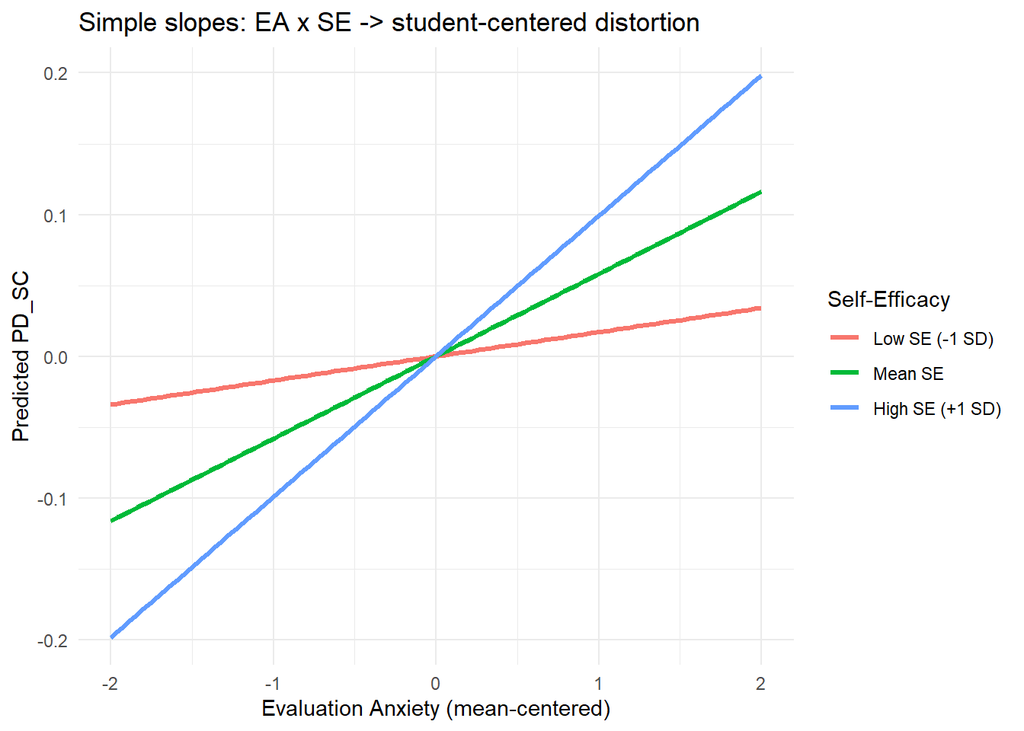

```r
###############################################################################
# Simple-slopes plot: EA x SE -> PD_SC
###############################################################################
pe_mlr <- parameterEstimates(fit_mlr, standardized = FALSE)
a1_hat <- pe_mlr$est[pe_mlr$lhs == "PD_SC" & pe_mlr$rhs == "EA_c"]
a3_hat <- pe_mlr$est[pe_mlr$lhs == "PD_SC" & pe_mlr$rhs == "EAxSE"]

ea_vals <- seq(-2, 2, length.out = 100)
se_vals <- c(-1, 0, 1) * sdSE
plot_dat <- expand.grid(EA_c = ea_vals, SE_c = se_vals)
plot_dat$PD_SC_hat <- a1_hat*plot_dat$EA_c + a3_hat*plot_dat$EA_c*plot_dat$SE_c
plot_dat$SE_label <- factor(plot_dat$SE_c, levels = se_vals,
                            labels = c("Low SE (-1 SD)","Mean SE","High SE (+1 SD)"))

print(
  ggplot(plot_dat, aes(EA_c, PD_SC_hat, color = SE_label)) +
    geom_line(linewidth = 1.1) +
    labs(x = "Evaluation Anxiety (mean-centered)",
         y = "Predicted PD_SC", color = "Self-Efficacy",
         title = "Simple slopes: EA x SE -> student-centered distortion") +
    theme_minimal()
)
```